# Group Assignment Training SME

Nzambuli Daniel

2023-11-15

```r
library(readxl)
SME_Training_Data <- read_excel("SME Training Data.xlsx")
head(SME_Training_Data)
```

```
## # A tibble: 6 × 16
##      ID Gender   Age Education Sector Location  Size Ageofbusiness   DAP TypeDAP
##   <dbl>  <dbl> <dbl>     <dbl>  <dbl>    <dbl> <dbl>         <dbl> <dbl>   <dbl>
## 1     1      2     3         4      6        3     3             3     2      NA
## 2     2      2     6         3      3        2     3             2     2      NA
## 3     3      2     5         2      1        3     2             5     2      NA
## 4     4      2     2         5      7        7     2             1     2      NA
## 5     5      2     6         2      3        3     2            NA     1       1
## 6     6      2     2         4      4        9     1             1     2      NA
## # ℹ 6 more variables: Learning <dbl>, Facility <dbl>, Typefacility <chr>,
## #   Frequency <dbl>, Operation <dbl>, Collaboration <dbl>
```

# Based on Region

## Add a columns for virtual learning, physical learning and combined learning

The columns shall be named

1. `face-2face` for physical
2. `online_learn` for virtual
3. `physical_virtual` for combined virtual and physical

```r
SME_Training_Data$face_2_face = as.factor(ifelse(SME_Training_Data$Learning == 1, 1, 0))
SME_Training_Data$online_learn = as.factor(ifelse(SME_Training_Data$Learning == 2, 1, 0))
SME_Training_Data$physical_virtual = as.factor(ifelse(SME_Training_Data$Learning == 3, 1, 0))
```

**Task**

1. Comparing diff regions to see what ways they are similar & where they differ
2. The `response variable` if they need the facility for training

*Note:* Include binary & ordinal responses but disregard categorical

### Re-label the factor columns

## Exploritory analysis

### Type of data in each column

```r
str(SME_Training_Data)
```

```
## tibble [301 × 19] (S3: tbl_df/tbl/data.frame)
##  $ ID              : num [1:301] 1 2 3 4 5 6 7 8 9 10 ...
##  $ Gender          : num [1:301] 2 2 2 2 2 2 2 1 1 2 ...
##  $ Age             : num [1:301] 3 6 5 2 6 2 4 2 2 2 ...
##  $ Education       : num [1:301] 4 3 2 5 2 4 3 4 4 2 ...
##  $ Sector          : num [1:301] 6 3 1 7 3 4 1 3 3 5 ...
##  $ Location        : num [1:301] 3 2 3 7 3 9 1 7 3 3 ...
##  $ Size            : num [1:301] 3 3 2 2 2 1 2 2 2 1 ...
##  $ Ageofbusiness   : num [1:301] 3 2 5 1 NA 1 4 2 1 3 ...
##  $ DAP             : num [1:301] 2 2 2 2 1 2 2 2 2 2 ...
##  $ TypeDAP         : num [1:301] NA NA NA NA 1 NA NA NA NA NA ...
##  $ Learning        : num [1:301] 1 3 3 1 3 1 3 3 1 3 ...
##  $ Facility        : num [1:301] 1 1 1 1 1 1 1 1 1 1 ...
##  $ Typefacility    : chr [1:301] "design" "cloth design" "hospitality" NA ...
##  $ Frequency       : num [1:301] 3 3 5 3 5 5 4 5 2 2 ...
##  $ Operation       : num [1:301] 3 3 2 3 5 1 3 2 3 3 ...
##  $ Collaboration   : num [1:301] 3 3 3 NA 2 NA 2 2 2 3 ...
##  $ face_2_face     : Factor w/ 2 levels "0","1": 2 1 1 2 1 2 1 1 2 1 ...
##  $ online_learn    : Factor w/ 2 levels "0","1": 1 1 1 1 1 1 1 1 1 1 ...
##  $ physical_virtual: Factor w/ 2 levels "0","1": 1 2 2 1 2 1 2 2 1 2 ...
```

```r
# gender 2 female 1 male
SME_Training_Data$Gender = as.factor(ifelse(SME_Training_Data$Gender == 2, "Female", "MALE"))
```

```r
SME_Training_Data$Education = as.factor(ifelse(
  SME_Training_Data$Education == 1, 'Primary', ifelse(
    SME_Training_Data$Education == 2, 'Secondary',
    ifelse(SME_Training_Data$Education == 3, 'Diploma',
           ifelse(
             SME_Training_Data$Education == 4, 'Undergraduate',
             ifelse(SME_Training_Data$Education == 5, 'Post Grad',
                    ifelse(SME_Training_Data$Education == 6, 'Other', SME_Training_Data$Education))
           ))
  )
))
```

```r
SME_Training_Data$Age = as.factor(ifelse(SME_Training_Data$Age == 1, 'below 20',
                                         ifelse(SME_Training_Data$Age == 2, '21 to 30',
                                                ifelse(SME_Training_Data$Age == 3, '31 to 40',ifelse(SME_Training_Data$Age == 4, '41 to 50',ifelse(SME_Training_Data$Age == 5, '51 to 60',ifelse(SME_Training_Data$Age == 6, 'above 60', SME_Training_Data$Age)))))))
```

```r
SME_Training_Data$Size = as.factor(ifelse(SME_Training_Data$Size == 1, '1', ifelse(
  SME_Training_Data$Size == 2, '2 to 4', ifelse(
    SME_Training_Data$Size == 3, '5 to 10',ifelse(
      SME_Training_Data$Size == 4, '11 to 49', ifelse(
        SME_Training_Data$Size == 5, 'above 50',SME_Training_Data$Size
      )
    )
  )
)))
```

```r
SME_Training_Data$Ageofbusiness = as.factor(ifelse(
  SME_Training_Data$Ageofbusiness == 1, '< 1 year',ifelse(
    SME_Training_Data$Ageofbusiness == 2, '1 to 3', ifelse(
      SME_Training_Data$Ageofbusiness == 3, '4 to 6', ifelse(
        SME_Training_Data$Ageofbusiness == 4, '6 to 10', ifelse(
          SME_Training_Data$Ageofbusiness == 5, '< 10 years', SME_Training_Data$Ageofbusiness
        )
      )
    )
  )
))
```

```r
SME_Training_Data$DAP = as.factor(ifelse(
  SME_Training_Data$DAP == 1, 'YES',ifelse(
    SME_Training_Data$DAP == 2, 'No', SME_Training_Data$DAP
  )
))
```

### Missing-ness of the data

```r
library(dplyr)
library(tidyverse)
library(finalfit)
```

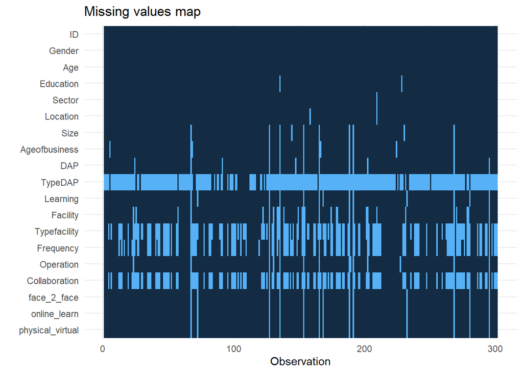

```r
missing_plot(SME_Training_Data)
```

### **Figure out the number of data points for each location in the data**

```r
location = SME_Training_Data$Location
min(location, na.rm = TRUE)
```

```
## [1] 1
```

```r
max(location, na.rm = TRUE)
```

```
## [1] 9
```

#### **Convert Na values to region 10**

```r
SME_Training_Data$Location[is.na(SME_Training_Data$Location)] = 10
```

```r
location = SME_Training_Data$Location
min(location)
```

```
## [1] 1
```

```r
max(location)
```

```
## [1] 10
```

### Re-code the data back to string

```r
locality = data.frame(town = location, count = rep(1, length(location)))
locality = locality %>% group_by(town) %>% summarise(count = sum(count))
locality
```

```
## # A tibble: 10 × 2
##     town count
##    <dbl> <dbl>
##  1     1     8
##  2     2    45
##  3     3    17
##  4     4    79
##  5     5    20
##  6     6    29
##  7     7    55
##  8     8    13
##  9     9    33
## 10    10     2
```

```r
#  'Ruaraka' = 1
#  'Embakasi' = 2
#  'Langata' = 3
#  'Starehe' = 4
#  'Mathare' = 5
#  'Kibra' = 6
#  'Dagoretti' = 7
#  'Westlands' = 8
#  'Roysambu' = 9
#  'Kasarani' = 10
#  'Kamukunji' = 11
#  'Other' = 12
locality$town = ifelse(locality$town == 1, 'Ruaraka', ifelse(
  locality$town == 2, 'Embakasi',ifelse(
    locality$town == 3, 'Langata',ifelse(
      locality$town == 4, 'Starehe',ifelse(
        locality$town == 5, 'Mathare',ifelse(
          locality$town == 6, 'Kibra',ifelse(
            locality$town == 7, 'Dagoreti',ifelse(
              locality$town == 8, 'Westlands',ifelse(
                locality$town == 9, 'Roysambu',ifelse(
                  locality$town == 10, 'other',locality$town
                  )
                )
              )
            )
          )
        )
      )
    )
  )
  )
locality
```

```
## # A tibble: 10 × 2
##    town      count
##    <chr>     <dbl>
##  1 Ruaraka       8
##  2 Embakasi     45
##  3 Langata      17
##  4 Starehe      79
##  5 Mathare      20
##  6 Kibra        29
##  7 Dagoreti     55
##  8 Westlands    13
##  9 Roysambu     33
## 10 other         2
```

**Ordinal Data**

1. Age group of Respondents `Age`
2. Education level `Education`
3. Region where the SME is located `Location`
4. Business size(number of employees) `Size`
5. Age of the business `Ageofbusiness`

**Binary Data**

1. Gender of respondent `Gender`
2. Facility needed `Facility`
3. Presence of Disabled persons `DAP`

The data for `location` was grouped into `near Nairobi` and `far from Nairobi` based on ease of walking from the town to the CBD

## Far from Nairobi

Far from towns are `Ruaraka, Embakasi, Dagoretti, Roysambu, Other`

Facility `2` is No and `1` is yes encoding is done such that yes becomes `1` and no becomes `0`

```r
library(dplyr, warn.conflicts = FALSE)

SME_Training_Data = SME_Training_Data %>% mutate(Facility = case_when(
  Facility == 1 ~ 1,
  Facility == 2 ~ 0,
  TRUE ~ Facility
))
SME_Training_Data$Location[is.na(SME_Training_Data$Location)] = 10
```

Far from Nairobi is location `1` this means all other locations are `0`

```r
far_data = SME_Training_Data %>% mutate(Location = case_when(
  Location == 1~1,
  Location == 2~1,
  Location == 7~1,
  Location == 9~1,
  Location == 10 ~ 1,
  TRUE ~Location
))
far_data = far_data %>% mutate(Location = case_when(
  Location != 1~0,
  TRUE ~Location
))
```

### Drop all columns that are not Binary or Ordinal

```r
colnames(SME_Training_Data)
```

```
##  [1] "ID"               "Gender"           "Age"              "Education"
##  [5] "Sector"           "Location"         "Size"             "Ageofbusiness"
##  [9] "DAP"              "TypeDAP"          "Learning"         "Facility"
## [13] "Typefacility"     "Frequency"        "Operation"        "Collaboration"
## [17] "face_2_face"      "online_learn"     "physical_virtual"
```

**Key columns**

1. Age - 3
2. Education - 4
3. Location - 6
4. Size - 7
5. AgeofBusiness - 8
6. DAP - 9
7. Gender = 2
8. Facility = 12
9. face_2_face = 17
10. online_learn = 18
11. physical_virtual = 19

```r
far_data = far_data[, c(2, 3, 4, 6, 7, 8, 9, 12, 17, 18, 19)]
colnames(far_data)
```

```
##  [1] "Gender"           "Age"              "Education"        "Location"
##  [5] "Size"             "Ageofbusiness"    "DAP"              "Facility"
##  [9] "face_2_face"      "online_learn"     "physical_virtual"
```

```r
far_cols = cbind(colnames(far_data)[1: 7], colnames(far_data)[9:11])
far_cols
```

```
##      [,1]            [,2]
## [1,] "Gender"        "face_2_face"
## [2,] "Age"           "online_learn"
## [3,] "Education"     "physical_virtual"
## [4,] "Location"      "face_2_face"
## [5,] "Size"          "online_learn"
## [6,] "Ageofbusiness" "physical_virtual"
## [7,] "DAP"           "face_2_face"
```

### contingency tables

facility `1` is yes they need the facility and `0` is no they do not need it

```r
for(col in far_cols){
  print(col)
  print(table(facility = far_data$Facility,
              far_data[[col]]))
}
```

```
## [1] "Gender"
##
## facility Female MALE
##        0     40   49
##        1     68  114
## [1] "Age"
##
## facility 21 to 30 31 to 40 41 to 50 51 to 60 above 60 below 20
##        0       57       16       10        3        0        3
##        1      104       40       24        9        4        1
## [1] "Education"
##
## facility Diploma Other Post Grad Primary Secondary Undergraduate
##        0      30     1         8       2        16            32
##        1      59     6         9       5        34            68
## [1] "Location"
##
## facility   0   1
##        0  43  46
##        1 101  81
## [1] "Size"
##
## facility  1 11 to 49 2 to 4 5 to 10 above 50
##        0 39        0     42       7        0
##        1 67        3     87      22        2
## [1] "Ageofbusiness"
##
## facility < 1 year < 10 years 1 to 3 4 to 6 6 to 10
##        0       24          2     48     10       4
##        1       35         12     83     35      14
## [1] "DAP"
##
## facility  No YES
##        0  79   8
##        1 156  25
## [1] "face_2_face"
##
## facility   0   1
##        0  45  43
##        1 120  59
```

[output cut: 15 more lines]

```
## [1] "online_learn"
##
## facility   0   1
##        0  85   3
##        1 167  12
## [1] "physical_virtual"
##
## facility   0   1
##        0  46  42
##        1  71 108
## [1] "face_2_face"
##
## facility   0   1
##        0  45  43
##        1 120  59
```

```r
for(col in far_cols){
  print(col)
  print(table(facility = far_data$Facility,
              far_data[[col]]))
  cat("\n\n\n")
  print(paste("Chi-squred test of", col))
  print(fisher.test(table(facility = far_data$Facility,
              far_data[[col]])))
}
```

```
## [1] "Gender"
##
## facility Female MALE
##        0     40   49
##        1     68  114
##
##
##
## [1] "Chi-squred test of Gender"
##
##  Fisher's Exact Test for Count Data
##
## data:  table(facility = far_data$Facility, far_data[[col]])
## p-value = 0.2377
## alternative hypothesis: true odds ratio is not equal to 1
## 95 percent confidence interval:
##  0.7903612 2.3611260
## sample estimates:
## odds ratio
##    1.36691
##
## [1] "Age"
##
## facility 21 to 30 31 to 40 41 to 50 51 to 60 above 60 below 20
##        0       57       16       10        3        0        3
##        1      104       40       24        9        4        1
##
##
##
## [1] "Chi-squred test of Age"
##
##  Fisher's Exact Test for Count Data
##
## data:  table(facility = far_data$Facility, far_data[[col]])
## p-value = 0.3008
## alternative hypothesis: two.sided
##
## [1] "Education"
##
## facility Diploma Other Post Grad Primary Secondary Undergraduate
```

[output cut: 218 more lines]

```
##
##
##
## [1] "Chi-squred test of face_2_face"
##
##  Fisher's Exact Test for Count Data
##
## data:  table(facility = far_data$Facility, far_data[[col]])
## p-value = 0.01569
## alternative hypothesis: true odds ratio is not equal to 1
## 95 percent confidence interval:
##  0.2957609 0.8972699
## sample estimates:
## odds ratio
##  0.5158606
```

**Interpret**

`face to face` data is the only data that has a p-value `<0.05` which indicates that the it is the best metric for predicting if individuals need the facilities

### Logistic model

considering the data set is small there is no split to train and test cases to ensure accuracy of prediction

#### Prepare the data

```r
far_data = far_data[!is.na(far_data$Facility), ]
```

```r
library(caTools)
library(ROCR)
```

```r
far_model = glm(Facility~.,
                    data = far_data, family = binomial)
summary(far_model)
```

```
##
## Call:
## glm(formula = Facility ~ ., family = binomial, data = far_data)
##
## Coefficients: (1 not defined because of singularities)
##                           Estimate Std. Error z value Pr(>|z|)
## (Intercept)                0.54050    0.48528   1.114   0.2654
## GenderMALE                 0.37907    0.30907   1.226   0.2200
## Age31 to 40               -0.12250    0.43286  -0.283   0.7772
## Age41 to 50               -0.52625    0.52612  -1.000   0.3172
## Age51 to 60               -0.01973    0.88869  -0.022   0.9823
## Ageabove 60               15.60966 1658.80952   0.009   0.9925
## Agebelow 20               -1.72946    1.20821  -1.431   0.1523
## EducationOther             1.12001    1.15319   0.971   0.3314
## EducationPost Grad        -1.10489    0.69036  -1.600   0.1095
## EducationPrimary          -0.18897    0.99013  -0.191   0.8486
## EducationSecondary         0.18863    0.47851   0.394   0.6934
## EducationUndergraduate     0.27919    0.34637   0.806   0.4202
## Location                  -0.33380    0.30127  -1.108   0.2679
## Size11 to 49              16.92310 1316.66732   0.013   0.9897
## Size2 to 4                -0.01662    0.32259  -0.052   0.9589
## Size5 to 10                0.27759    0.58913   0.471   0.6375
## Sizeabove 50              14.93450 1681.17985   0.009   0.9929
## Ageofbusiness< 10 years    1.06702    1.02692   1.039   0.2988
## Ageofbusiness1 to 3        0.09679    0.38249   0.253   0.8002
## Ageofbusiness4 to 6        0.84023    0.58966   1.425   0.1542
## Ageofbusiness6 to 10       1.09261    0.74232   1.472   0.1411
## DAPYES                     0.29917    0.52416   0.571   0.5682
## face_2_face1              -0.66552    0.30840  -2.158   0.0309 *
## online_learn1              0.93132    0.84201   1.106   0.2687
## physical_virtual1               NA         NA      NA       NA
## ---
## Signif. codes:  0 '***' 0.001 '**' 0.01 '*' 0.05 '.' 0.1 ' ' 1
##
## (Dispersion parameter for binomial family taken to be 1)
##
##     Null deviance: 324.81  on 256  degrees of freedom
## Residual deviance: 292.21  on 233  degrees of freedom
##   (14 observations deleted due to missingness)
## AIC: 340.21
##
## Number of Fisher Scoring iterations: 15
```

**Seeing if the key predictor value improves the model prediction**

```r
far_model_2 = glm(Facility~ face_2_face,
                    data = far_data, family = binomial)
summary(far_model_2)
```

```
##
## Call:
## glm(formula = Facility ~ face_2_face, family = binomial, data = far_data)
##
## Coefficients:
##              Estimate Std. Error z value Pr(>|z|)
## (Intercept)    0.9808     0.1748   5.611 2.01e-08 ***
## face_2_face1  -0.6645     0.2660  -2.498   0.0125 *
## ---
## Signif. codes:  0 '***' 0.001 '**' 0.01 '*' 0.05 '.' 0.1 ' ' 1
##
## (Dispersion parameter for binomial family taken to be 1)
##
##     Null deviance: 338.50  on 266  degrees of freedom
## Residual deviance: 332.25  on 265  degrees of freedom
##   (4 observations deleted due to missingness)
## AIC: 336.25
##
## Number of Fisher Scoring iterations: 4
```

The second model is better at discriminating if individuals will need the facility or not as the AIC value is `1.163987%` smaller

This means that a person will be less likely to need the facilities if they are physical than if they are not physical.

### Prediction and Accuracy

```r
pred_far = predict(far_model_2)
pred_far = ifelse(pred_far> 0.5, 1, 0)
reg_tab_far = table( actual_data = far_data$Facility , predicted = pred_far[1:271])
reg_tab_far
```

```
##            predicted
## actual_data   0   1
##           0  37  49
##           1  65 116
```

#### accuracy

```r
acc_far = mean(pred_far == far_data$Facility)
acc_far
```

```
## [1] 0.5682657
```

```r
odds_rat_far = exp(coef(far_model_2))
odds_rat_far
```

```
##  (Intercept) face_2_face1
##    2.6666667    0.5145349
```

This backs up the initial model coefficient claim that a person is less likely to need the facilities if they are face to face